# Model ThreeMe Tunisia

Macroeconomic impacts of National Low-Carbon Strategy for a little country in development : the case of Tunisia

Lucia SEQUEIRA - Bijan VALILOU - Jin WANG

January 2022

# Introduction

## Energy and economy framework in Tunisia

Tunisia is one of the northernmost countries in Africa, ranked the most competitive economy in Africa by World Economy Forum in 2009 (“Tunisia” 2022). The local economy is largely oriented towards services, which account for 43% of GDP in 2019 (World Bank 2020), including the booming IT and tourism industries. Agriculture is another key sector of the Tunisian economy, representing 10.4% of the GDP and employing 12.7% of the working population (World Bank 2020). Thanks to technical progress of agricultural sector, Tunisia is one of the most productive countries in Africa. Tunisia’s industry represents 22.7% of GDP and employs 32.5% of the working population in 2020 (BNPPariBas, n.d.). The industrial sectors are mainly export oriented especially for manufacturing, Europe is the destination for more than 75% of Tunisia’s exports (World Bank 2020).

Since the Jasmine Revolution on 2011, Tunisia economy has been suffered from the extended recession. The sanitary crisis on 2020 has worsened the already precarious situation. Actually, even before COVID-19 Tunisia’s capacity for economic resilience had been drained by years of indecisive public policy-making and growing protectionism (World Bank, n.d.). In early September 2020, the Tunisian parliament finally reversed a government of Tenchnocrats in an attempt to remedy the country’s economic situation (BNPPariBas, n.d.).

Along with the sluggish economy is the huge energy deficit in Tunisia. IRENA (2021) reported that energy deficit (50% in 2019) has existed in Tunisia over the past two decades, mainly because of the increasing consumption but with the stagnated even declined domestic production in recent years. GIZ (n.d.) reported that Tunisia depends for 60% on energy imports, and this number is continuously raising. The energy transition project proclaimed in 2014 aims to reduce energy needs by 34% by 2030, lower subsidies and establish incentive mechanisms favoring profitable and climate friendly investments. However, the challenging is the lack of reliable institutional mechanisms and motivation for enterprises to participate, accompanied with a poorly established service market and weak transmission of knowledge to citizens, especially outside urban area.

After the revolution, fiscal and equity issues incited the Tunisian government to reduce energy subsidies. In 2012, the prices of gasoline, diesel and electricity increased by 7% (Albertin et al. 2014). In 2014, energy subsidies to cement firms were reduced by half. In 2020, Tunisia has introduced an automatic monthly price adjustment mechanism for petrol and diesel sales, with the aim of eliminating fuel subsidies.

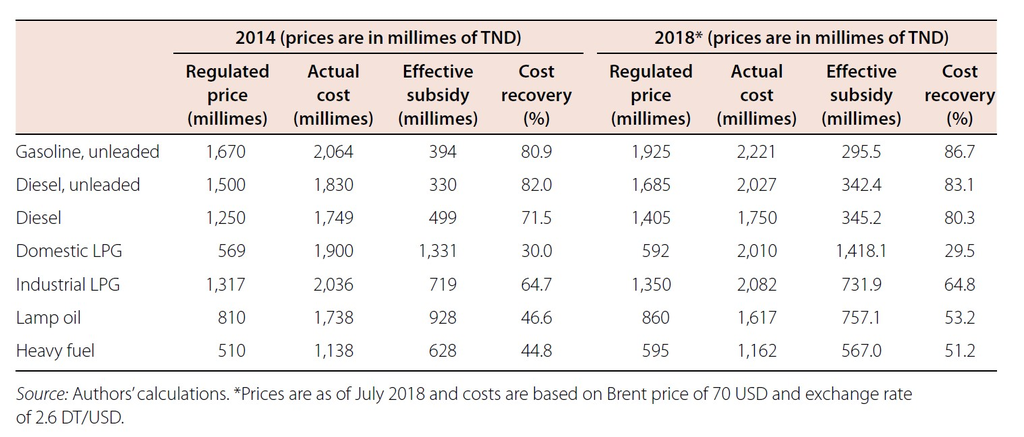

Fig.1 : Composition of fuel subsidies product (source : *Tunisia Public Expenditure Review* (2020))

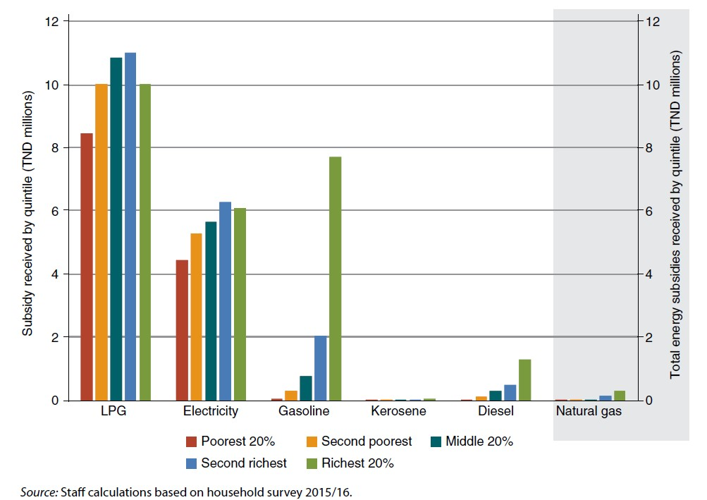

Fig.2 : Energy subsidies received by welfare quintile, 2015/16 (TND millions) (source : *Tunisia Public Expenditure Review* (2020))

## Literature review in climate policy

### Carbon tax

In general, the presence of an environmental externality suggests that there is a marginal social cost that exceeds the marginal private cost. In the absence of regulation, the difference between this two costs (the marginal external cost of damage) is not covered by the polluter. Consider the particular case of the externalities associated with the release of CO2 in the atmosphere. The carbon tax is the tax that comes reflect that marginal external damage.

The advantage of using a tax system to price environmental harm is to send a clear price signal to guide economic entities spontaneously to reduce their level of pollution, until their marginal cost of depollution equals the tax (de Perthuis, Shaw, and Lecourt 2010) .

After some reversals over the past twenty years, carbon pricing is reemerging. Since 2016, many new carbon-pricing initiatives have been implemented, with several countries considering implementing carbon pricing in the years ahead, after having signed the Paris Agreement (Klenert et al. 2018). The level of the carbon price retained, i.e. the rate of the tax, corresponds in someway to the value that society places on the protection of the environment from the consequences of a rise in temperature (de Perthuis, Shaw, and Lecourt 2010).

In a competitive market, the introduction of a carbon tax will cause private costs to rise and in consequence its implementation encounters considerable resistance. It is then desirable to accompany carbon taxes with some mechanism that enhance its acceptability.

### Energy subsidy

Subsidies are defined by Moor and Calamai (1997) as *‘any measure that keeps prices for consumers below the market level or keeps prices for producers above the market level or that reduces costs for consumers and producers by giving direct or indirect support’*. Energy subsidies are a common policy. Their amount is estimated at $4.7 trillion in 2015 as pointed out Coady et al. (2019), which is equivalent to 6.3 percent of Gross Domestic Product . Energy subsidies fluctuate depending on the price of the energy products. From the database of the International Energy Agency, we can notice that the fossil fuel subsidies have [fallen by 42 percent between 2019 and 2020](https://www.iea.org/topics/energy-subsidies) due to the drop of fuel prices.

The energy subsidies are very present in the Middle East, North Africa, Afghanistan and Pakistan region (MENAP). According to Coady et al. (2019), MENAP is the fourth region in absolute terms, which subsidized the most energy in 2015. Nevertheless, in relative terms, MENAP is the second, if we take into account the percent of its GDP. The prevalence of energy subsidies in MENAP can be explained by the post-par period. These energy subsidies were introduced, after the decolonization, in Middle East and North Africa region (MENA) in order to stabilize prices and then, became a social protection system (Verme 2017).

Fattouh and El-Katiri (2013) emphasize three positive aspects of the energy subsidies that we saw above :

- The energy subsidies enhance the incomes of the poorest part of the population. It constitute a core part of the welfare system in the MENA.
- The energy subsidies help to reduce production costs and to strengthen competitiveness of local firms. Energy subsidies are a tool for industrialization and diversification policy.
- The regulation of energy prices is used to control inflation and stabilize prices.

Reducing energy subsidies may improve economic welfare and reduce emissions (Aldy and Patashnik 2013 ; Coady et al. 2019 ; Hahn and Metcalfe 2021). Fattouh and El-Katiri (2013) also highlight unintended consequences of energy subsidies :

- Energy subsidies raise energy intensity of GDP and reduce energy efficiency rates. Low energy pricing favors the growth of energy-intensive industries and discourage the firms from minimizing energy costs. Fig. 3 below shows that many energy-intensive countries have also high fossil fuel subsidies as a proportion of their GDP.
- Energy subsidies distort consumption. Indeed, they cause a fast growth in consumption of primary fuels and electricity. According to Fattouh and El-Katiri (2013), between 1980 to 2008, the total energy consumption in MENA grew more than 5% annually.
- Energy subsidies distort investments. The weak implementation of subsidies provoke underinvestment in energy sectors, where the subsidies do not entirely compensate the energy companies. Therefore, end users receive a low quality service.
- Energy subsides cause fuel shortages because of low prices. The smuggling across borders is also favored by the price differences between countries.
- Non-targeted subsidies create inequities between social groups (see fig. 2 above).

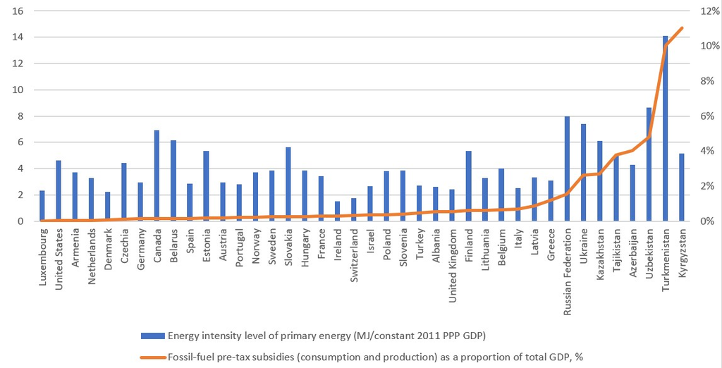

Fig.3 : Energy subsidies and energy intensities by country in 2017 (data : SDG indicators for United Nations Economic Commission for Europe)

### Carbon tax revenue recycling and double dividend

Tax redistribution is the mechanism that allows the government to return to the private economy the revenues that are produced by the instrument (Goulder 2013). There are many ways in which this redistribution can operate.

Most of the times, redistribution is presented as a lump-sum transfer to households and firms, or as a reduction in taxes that introduce a deformation into the economy as it is the case of labor taxes. Klenert et al. (2018) findings suggest that lump-sum transfers are more stable over time, particularly in countries that are stuck in issues of economic inequality, political distrust and polarization.

In fact, there are no generalities regarding the way the revenues are recycled. Some authors give general lines about which type of redistribution to chose depending on economic and sociopolitical circumstances. An example of that is the diagram tree below, oriented to help decision.

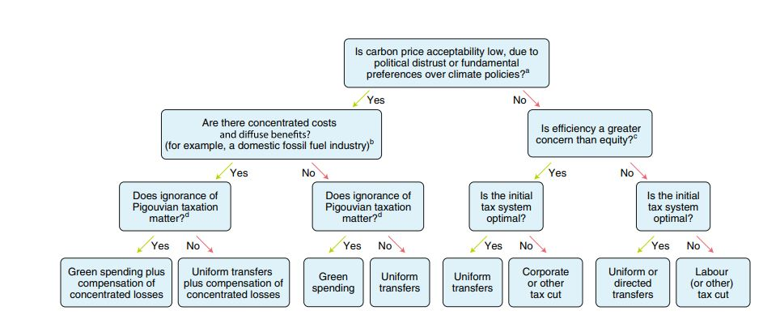

Fig.4 : Decision-tree diagram for carbon revenue recycling. Source : Klenert et al. (2018) .

The choice of the type of redistribution has a important role in determining the existence or absence of a double dividend and its importance. However, there are other leverages that are also important, such as the ease with which economic agents can substitute goods, the degree of exposure to foreign competition and the type of representation of the wage equation (the latter has an important role in a Neo-Keynesian framework, which is the case of the ThreeME model).

# Methodology

## ThreeME model

The ThreeME model is a hybrid neo-Keynesian Computable General Equilibrium model (1), which had to be adaptated and calibrated on Tunisian data (2).

### A hybrid neo-Keynesian Computable General Equilibrium model

The [open source](https://github.com/fosem/ThreeME_V3-open) ThreeME model has been developped since 2008 by OFCE (French Economic Observatory), ADEME (French Environment and Energy Management Agency) and NEO (Netherlands Economic Observatory). ThreeME is a Computable General Equilibrium Model (CGEM), with neo-Keynesian features and a hybrid structure.

ThreeME combines several features (Callonnec et al. 2013, 2021) :

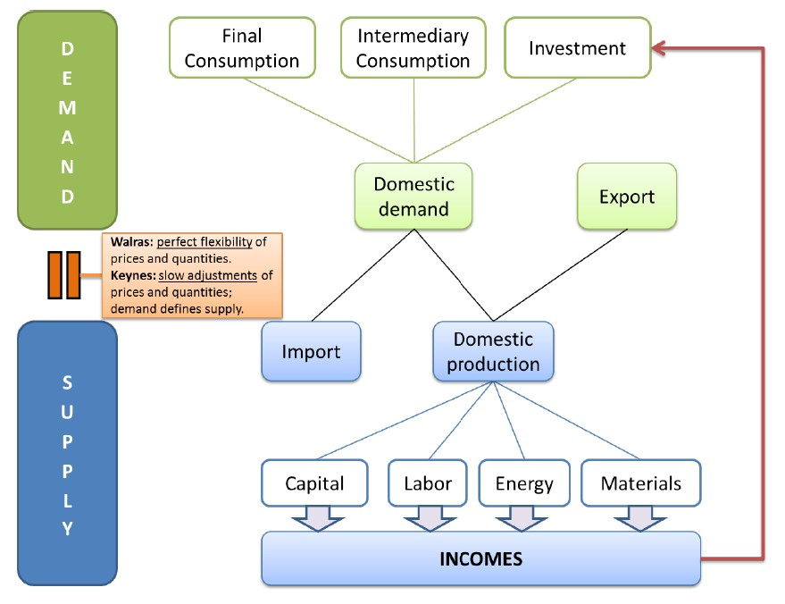

Fig.5 : Architecture of CGEM (source : Callonnec et al. (2013))

- ThreeME is a CGEM of neo-Keynesian inspiration. ThreeME differs from Walrasian CGEM in its dynamics and its transition to the long run. Instead of perfect flexibility hypothesis, prices and quantities slowly adjust, because of uncertainties, adjustment costs or temporal boundaries. Prices do not clear supply and demands and market imperfections are also included in the model. Consequently, there are disequilibrium between supply and demand. For instance, involuntary unemployment is possible.
- The high sectoral disaggregation is a way to describe the transfers of activity from a sector to another. The ThreeME model allows to track sectoral changes in investment, employment or energy consumption.
- ThreeME is a hybrid model which combines top-down and bottom-up modelling. On one side, the general equilibrium effets are represented. On the other side, the energy disaggregation allows for the analysis of the energy production and consumption. The trade-offs between energy and other production factors and between several energy consumptions are included in the model.

### ThreeMe model Tunisia : Adaptation for a little country in development

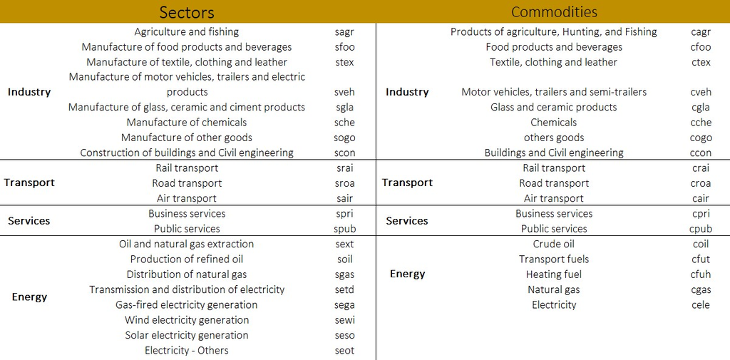

Fig.6 : Sectoral disaggregation

The required data are economic data from national accounts, in particular from Input-Output Tables (IOTs), physical data from energy balance and detailed tax data by product. These data were collected from Tunisian institutions, in particular ANME (National Agency for Energy Management), INS (National Institute of statistics), ONE (National Energy Observatory), STEG (Tunisian Company of Electricity and Gas), ITCEQ (Tunisian Institute of Competitiveness and Quantitative Studies), Ministry of Energy, Mines and Energy Transition and the Ministry of Economic Development, Investment and International Cooperation.

## Description of scenarios

We work on six different scenarios that simulate the implementation of six alternative environmental policies. For both policies carbon tax and fossil fuels subsidies removal, there are two scenarios. The first one assuming there is no recycling of revenues and the second one considering some type of recycling of revenues.

- Scenario 1 : Implementation of a carbon tax from 2021 without redistribution of the revenues of the tax in the economy - they are used to reduce public debt.
- Scenario 2 : Carbon tax with recycling of revenues that are redirected to the Energy Transition Fund. In fact, a part is given back to households and a portion is devoted to “non-polluting” businesses.
- Scenario 3 : Fossil fuels subsidies removal (without recycling).
- Scenario 4 : Fossil fuels subsidies removal (with recycling). A part is given back to households and a portion is given to enterprises in proportion to the employment of each sector in the total salaried labor force.
- Scenario 5 : Significant penetration of Renewable Energies in the electrical mix (80% by 2050)
- Scenario 6 : Combination of scenarios 2, 4 and 5.

### Carbon tax evolution

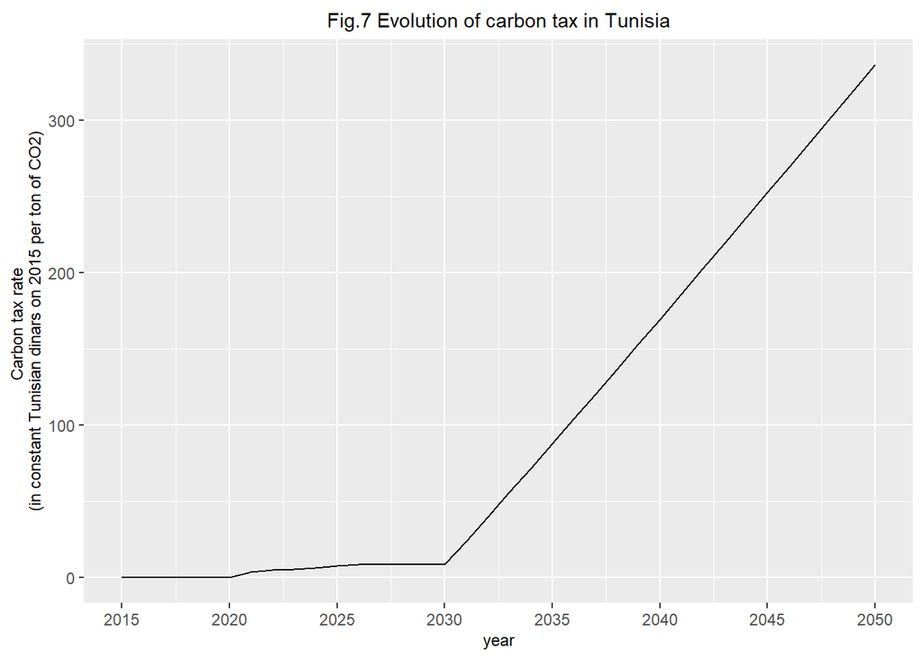

### Fossil fuels subsidies removal over time

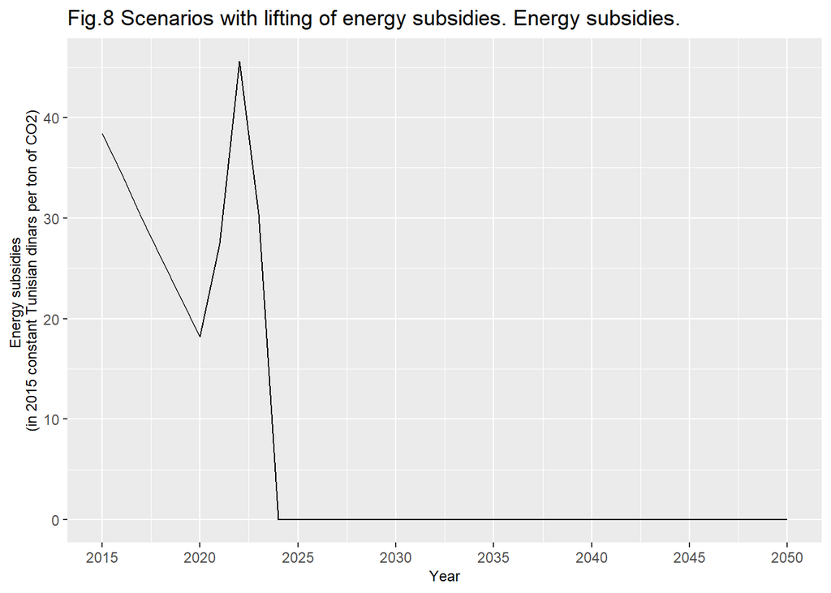

## Choice of evaluation indicators

### Data structure

The analysed data are derived from outputs of model ThreeME Tunisia. All the indicators are simulated from 2015 to 2050, generating a database with time series. The indicators used in the analysis if not exceptionally mentioned are in percentage relative form, meaning the proportional variation to Baseline scenario:

$$X = \frac{X_{Shock}}{X_{Baseline}} \times 100\% \tag{1}$$
where:

- $X$ is the indicator used for analysis;
- $X_{Shock}$ is the model output with different policy scenarios;
- $X_{Baseline}$ is the model output with baseline scenario;

### Kaya identity

The Kaya identity, firstly proposed by (KAYA 1989), is an identity where the total emission of carbon dioxide can be explained by four product driving forces as population, Gross Domestic Product (GDP) per capita, enerny intensity over GDP and carbon intensity over energy consumption (“Kaya Identity” 2021). It is expressed in the form:

$$C = POP \cdot \frac{GDP}{POP} \cdot \frac{TEC}{GDP} \cdot \frac{C}{TEC} \tag{1}$$

where:

- POP is global population;
- GDP is gross domestic product;
- TEC is total energy consumption;
- C is total emission of carbon dioxide;

And:

- GDP/POP is GDP per capita describing the economical activities within a period;
- TEC/GDP is energy intensity;
- C/TEC is carbon intensity;

In this study, we introduced an extension of Kaya identity to explain how different driving forces influenced the total emission for different scenarios. Firstly, a extended Kaya identity is used to analysis CO<sub>2</sub> emission with the aggregated factors, then we couple with Logarithmic Mean Divisia Index (LMDI) method to decomposite CO<sub>2</sub> emission at the sectorial level.

We modified the function of Kaya identity mentioned above to adapt our model assumption, where we integrated a new driving force, named economy structure, to decomposite emissions driving force at sectorial level. The five economic sectors considered in ThreeME Tunisia model are: Industry and Agriculture, Service, Transportation, Energy Transformation and Electricity. However, we did not take population into consideration because its increasing rate remains still over time for all our scenarios and is considered as an exogenous variable in ThreeME model.

Therefore, the CO<sub>2</sub> emission can be written as:

$$EM_{tot} = \Sigma EMA_{i} = \Sigma( VA \cdot \frac{VA_{i}}{VA} \cdot \frac{EC_{i}}{VA_{i}} \cdot \frac{CE_{i}}{EC_{i}} )= \Sigma( V \cdot S_{i} \cdot E_{i} \cdot I_{i}) \tag{2}$$
where EM<sub>tot</sub> is overall CO<sub>2</sub> emission, EM<sub>i</sub> is CO<sub>2</sub> emission of economic sector i, VA is total added value, VA<sub>i</sub> is added value of sector i, EC<sub>i</sub> is total energy consumption by sector i, CE<sub>i</sub> is CO<sub>2</sub> emission arising from sector i. According to equation 8, total CO<sub>2</sub> emission can be explained by four driving forces, including one aggregated indicator, overall economic activities VA, and three sectorial indicators, share of total added value of sector i S<sub>i</sub>, energy intensity over added value of sector i E<sub>i</sub> and carbon intensity over energy consumption of sector i I<sub>i</sub>. Especially, S<sub>i</sub> can be interpreted as economy structure of Tunisia, Grubb et al. (2015) and Kanitkar, Banerjee, and Jayaraman (2015) found that for a developing country, this term could be a key variable determining the future emissions pathway.

The effects of driving forces can be expressed in two ways: multiplicative and additive form, where multiplicative deviation $D_{tot}$ is the ratio of total CO<sub>2</sub> emission between policy scenario and baseline scenario (equation 3), and additive deviation $\Delta EM_{tot}$ is the difference of total CO<sub>2</sub> emission (equation 4). The two expressions are shown below:

$$D_{tot} =\frac{C_{2}}{C_{0}} = \Pi(\frac{V_{2}}{V_{0}} \cdot \frac{S_{2,i}}{S_{0,i}} \cdot \frac{E_{2,i}}{E_{0,i}} \cdot \frac{I_{2,i}}{I_{0,i}}) = D_{V} \cdot D_{S} \cdot D_{E} \cdot D_{I} = D_{V} \cdot \Pi ( D_{S_{i}} \cdot D_{E_{i}} \cdot D_{I_{i}}) \tag{3}$$

$$\Delta EM_{tot} = EM_{2} - EM_{0} = \Delta EM_{VA} + \Delta EM_{S} + \Delta EM_{E} + \Delta EM_{I} = \Delta EM_{V} + \Sigma( \Delta EM_{S_{i}} + \Delta EM_{E_{i}} + \Delta EM_{I_{i}}) \tag{4}$$
where subscript $tot$ represents overall change of emission, subscript 0 and 2 mean baseline scenario and policy scenario respectively. Hence we obtain the index $D_{V}$, $D_{S}$, $D_{E}$ and $D_{I}$, meaning the deviation of emissions due to change of overall economic activities, economy structure, energy intensity and carbon intensity, while $\Delta EM_{V}$, $\Delta EM_{S}$, $\Delta EM_{E}$ and $\Delta EM_{I}$ depict the difference of emissions related to change of driving forces.

Now we expect to identify the effect of each driving force at a sectorial level, to do this, we used a LMDI method proposed by Ang and Choi (1997) and Ang (2005). For multiplicative form, we have:

$$D_{X} = exp ( \Sigma \frac{(EM_{2,i}-EM_{0,i})/(lnEM_{2,i}-lnEM_{0,i})}{(EM_{2}-EM_{0})/(lnEM_{2}-lnEM_{0})} \cdot ln \frac{X_{2,(i)}}{X_{0,(i)}} ) \tag{11}$$
$$\Delta EM_{X} = \Sigma (\frac{EM_{2,i}-EM_{0,i}}{lnEM_{2,i}-lnEM_{0,i}} \cdot ln\frac{X_{2,(i)}}{X_{0,(i)}}) \tag{12}$$
where $EM_{2}$ is total emission of policy scenario, $EM_{0}$ is total emission of baseline, $EM_{2,i}$ is emission of policy scenario arising from sector i, $EM_{0,i}$ is emission of baseline arising from sector i, $D_{X}$ and $\Delta EM_{X}$ represent multiplicative and additive index of driving force $X$, $X_{2,(i)}$ is value of driving force $X$ of policy scenario for sector i, $X_{0,(i)}$ is value of driving force $X$ of baseline for sector i.

It should be noted that we integrated the energy consumption and carbon dioxide emission by household into that of energy transformation sector. On the one hand, household is the aggregation who does not hold added value, but who, at meantime, does contribute to the overall CO2 emissions, however, the emissions arose by households are certainly not negligible. On the other hand, the households consume principally fuels, natural gas and electricity, where the first two are derived from energy transformation sector. As for electricity, the usage of electricity in fact does not arise any emissions according to the assumptions for it is taken into consideration during its generation i.e. electricity sector. This may not be the best solution, however, it does not change our principal results but largely simplify the data treatment process. So we consider, for the following analysis, that for energy transformation sector the consumption of fuels for transportation, fuels for other uses and electricity are derived from households, whilst the natural gas consumption belongs to the sector itself.

# Results and discussions

In this section we will analyse the results obtained for the different scenarios for the different variables taken into account.

## Importance of redistribution

In this section we will analyse the influence of the redistribution of both the carbon tax and the removed energy subsidies. We will observe the impact of the redistribution on both the economical and on the environmental aspect. We will focus on GDP and employment variations among other indicators when it comes to the economical aspect and we will analyse the evolution of CO2 emissions for the environmental aspect.

### Carbon tax with and without redistribution

We first analyse the redistribution of the carbon tax. The figure below shows the variation in GDP in relation to the baseline for both scenarios carbon tax with and without redistribution. We observe that the scenario with redistribution shows a marked increase in GDP since 2030 (+2% in 2050 in relation to the baseline) while GDP decreases for the scenario without redistribution (-1.5% in 2050 in comparison with the baseline). The variations in GDP observed before 2030 are less pronounced, and that correspond to the progressive implementation of the carbon tax.

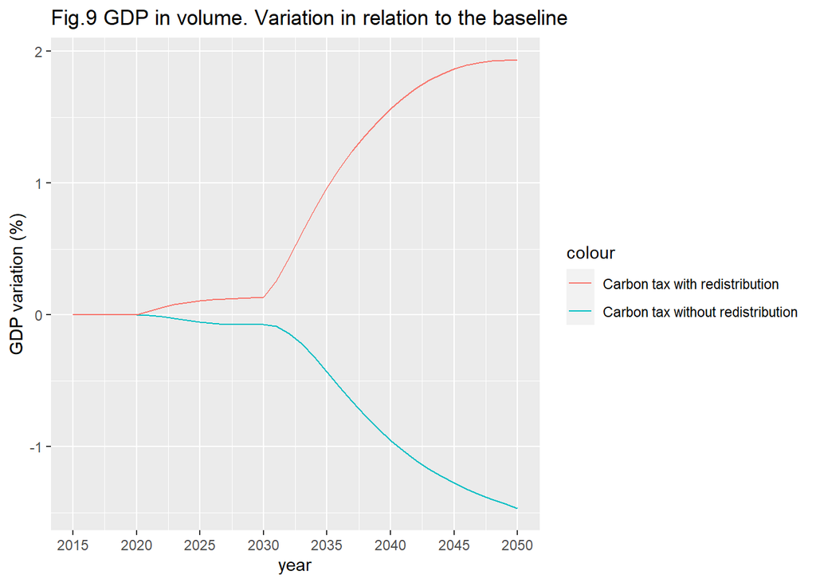

If we analyse employment variations, we can see that the redistribution operates an increase on it in relation to the baseline (+2.3% in 2050). In the scenario without redistribution there is a decrease in the level of employment in comparison with the baseline (-1% in 2050).

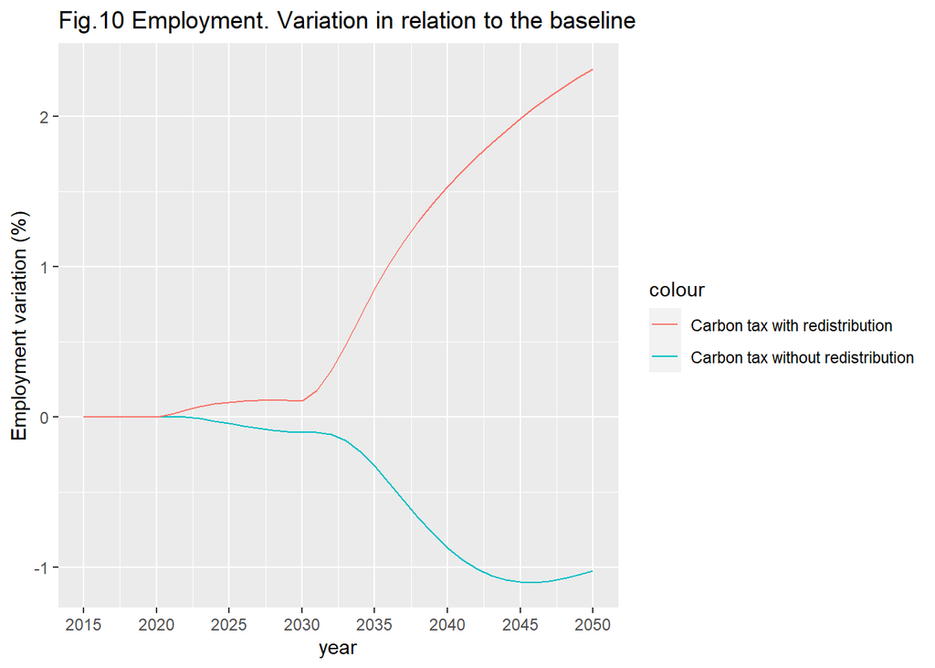

Regarding CO2 emissions, it is noted that there is not a great difference in the variation between the scenarios carbon tax with and without redistribution. However, we can notice that the reduction in emissions compared to the baseline is slightly larger in the case that there is no redistribution, and this seems consistent with the economic recession observed before.

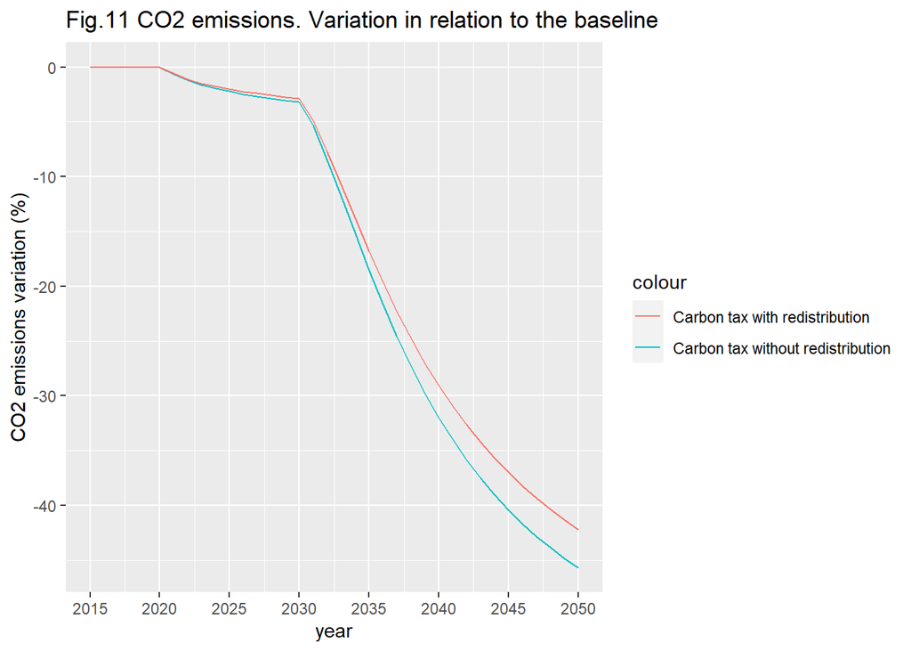

In order to have a deeper comprehension of the effects of tax recycling we will analyse further economic indicators that account for the state of the Tunisian economy. The figures in the two tables below represent the variation in relation to the baseline for each indicator at a given time.

We can initially notice that redistribution tends to increase household consumption. This is intimately related to the type of redistribution chosen. As explained before, a part of the carbon tax revenues is given back to households as lump-sum transfers and this allows consumption to rise (even if moderately) despite the increase on production prices.

Regarding public debt, we notice that it decreases in the two cases despite the presence or absence of redistribution. However, the decrease is much more pronounced in the scenario without redistribution, what seems reasonable since the revenues of the carbon tax are almost exclusively devoted to pay off the public debt.

Macroeconomic impacts of carbon tax scenario without redistribution in percent deviation to Baseline

|  | 2021 | 2025 | 2030 | 2035 | 2040 | 2045 | 2050 |
| --- | --- | --- | --- | --- | --- | --- | --- |
| GDP in volume | 0.00 | -0.05 | -0.07 | -0.43 | -0.95 | -1.28 | -1.47 |
| Household consumption | -0.05 | -0.15 | -0.18 | -1.54 | -2.39 | -2.21 | -1.62 |
| Investment | 0.00 | -0.09 | -0.15 | -0.68 | -1.28 | -0.96 | 0.00 |
| Exports | 0.00 | -0.05 | -0.13 | -0.56 | -1.57 | -2.79 | -3.88 |
| Imports | -0.06 | -0.18 | -0.25 | -1.81 | -2.97 | -2.92 | -2.18 |
| Household disposable income | -0.07 | -0.15 | -0.18 | -1.59 | -2.35 | -2.17 | -1.62 |
| Household consumption price index | 0.07 | 0.22 | 0.38 | 2.39 | 5.28 | 8.17 | 10.58 |
| production price index | 0.05 | 0.23 | 0.41 | 2.51 | 5.94 | 9.57 | 12.65 |
| Added value price index | -0.04 | 0.10 | 0.28 | 1.00 | 4.01 | 7.80 | 11.33 |
| Intermediate consumption price index | 0.14 | 0.37 | 0.55 | 4.17 | 8.12 | 11.58 | 14.13 |
| Export price index | 0.03 | 0.14 | 0.27 | 1.52 | 3.67 | 5.93 | 7.82 |
| Import price index | -0.01 | -0.10 | -0.12 | -0.63 | -0.81 | -0.90 | -1.00 |
| Gross nominal wage | 0.00 | 0.11 | 0.27 | 1.09 | 3.42 | 6.35 | 9.06 |
| Real cost of labor | 0.04 | 0.01 | -0.01 | 0.08 | -0.57 | -1.36 | -2.06 |
| Wage employment rate (in thousands) | 0.07 | -1.67 | -4.01 | -13.17 | -35.88 | -45.85 | -43.00 |
| Unemployment rate (in point) | 0.00 | 0.03 | 0.06 | 0.20 | 0.50 | 0.62 | 0.56 |
| Trade balance (in point of GDP) | 0.05 | 0.25 | 0.35 | 1.96 | 3.09 | 3.44 | 3.39 |
| Public budget balance (in points of GDP) | 0.09 | 0.22 | 0.31 | 1.86 | 2.72 | 3.26 | 3.49 |
| Public debt (in points of GDP) | -0.13 | -0.89 | -2.06 | -8.68 | -18.39 | -29.00 | -39.20 |
| CO2 emissions | -0.64 | -2.22 | -3.20 | -18.53 | -31.99 | -40.42 | -45.67 |

Macroeconomic impacts of carbon tax scenario with redistribution in percent deviation to Baseline

|  | 2021 | 2025 | 2030 | 2035 | 2040 | 2045 | 2050 |
| --- | --- | --- | --- | --- | --- | --- | --- |
| GDP in volume | 0.03 | 0.11 | 0.13 | 0.97 | 1.56 | 1.87 | 1.93 |
| Household consumption | 0.02 | 0.13 | 0.20 | 1.04 | 2.12 | 3.29 | 4.20 |
| Investment | 0.03 | 0.07 | 0.10 | 0.74 | 1.47 | 2.62 | 3.96 |
| Exports | 0.00 | -0.03 | -0.09 | -0.36 | -1.20 | -2.32 | -3.36 |
| Imports | -0.03 | -0.02 | -0.03 | -0.40 | -0.44 | 0.20 | 1.13 |
| Household disposable income | 0.03 | 0.14 | 0.19 | 1.07 | 2.12 | 3.27 | 4.17 |
| Household consumption price index | 0.05 | 0.17 | 0.33 | 1.89 | 4.51 | 7.24 | 9.49 |
| production price index | 0.03 | 0.17 | 0.35 | 1.88 | 4.99 | 8.43 | 11.33 |
| Added value price index | -0.07 | 0.02 | 0.19 | 0.23 | 2.84 | 6.42 | 9.76 |
| Intermediate consumption price index | 0.13 | 0.33 | 0.51 | 3.70 | 7.42 | 10.73 | 13.14 |
| Export price index | 0.01 | 0.09 | 0.21 | 1.02 | 2.91 | 5.02 | 6.80 |
| Import price index | -0.01 | -0.09 | -0.11 | -0.58 | -0.75 | -0.83 | -0.92 |
| Gross nominal wage | 0.00 | 0.10 | 0.27 | 1.03 | 3.32 | 6.26 | 8.92 |
| Real cost of labor | 0.07 | 0.08 | 0.07 | 0.79 | 0.44 | -0.19 | -0.81 |
| Wage employment rate (in thousands) | 0.70 | 3.82 | 4.29 | 34.47 | 63.39 | 82.96 | 97.35 |
| Unemployment rate (in point) | -0.01 | -0.06 | -0.06 | -0.50 | -0.87 | -1.11 | -1.29 |
| Trade balance (in point of GDP) | 0.03 | 0.15 | 0.23 | 1.17 | 1.89 | 2.12 | 2.07 |
| Public budget balance (in points of GDP) | 0.01 | 0.12 | 0.20 | 0.88 | 1.56 | 2.04 | 2.23 |
| Public debt (in points of GDP) | -0.05 | -0.49 | -1.25 | -4.81 | -10.69 | -17.51 | -24.33 |
| CO2 emissions | -0.61 | -2.00 | -2.90 | -16.79 | -29.06 | -36.98 | -42.22 |

### Fossil fuels subsidies removal with and without redistribution

If we do the same analyse on the economic indicators for the scenarios subsidies removal with and without redistribution, we notice that in general lines trends are similar.

In the case of GDP variation for the scenario with redistribution, we can see in the figure below that there is a maximum increase of approximately 0.5% around the year 2024 when the subsidies fall to zero. Then there is an stabilization in GDP around baseline levels. For the scenario subsidies removal without redistribution, there is a strong decrease in GDP variation around 2028 (-2.1% in relation to the baseline), and then a progressive increase. However, GDP variation is always negative in comparison to the baseline at least in the period 2020-2050.

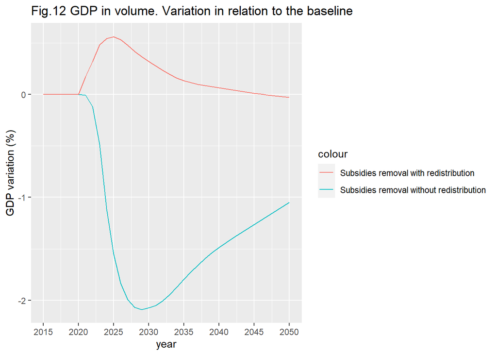

As regards employment, the scenario with redistribution presents a positive variation in relation to the baseline for the period 2020-2030, and then a negative one between 2030 and 2045. This variation is in absolute terms always below 0.5%. If we consider the scenario without redistribution we observe a negative variation that goes beyond -2.5% around 2030.

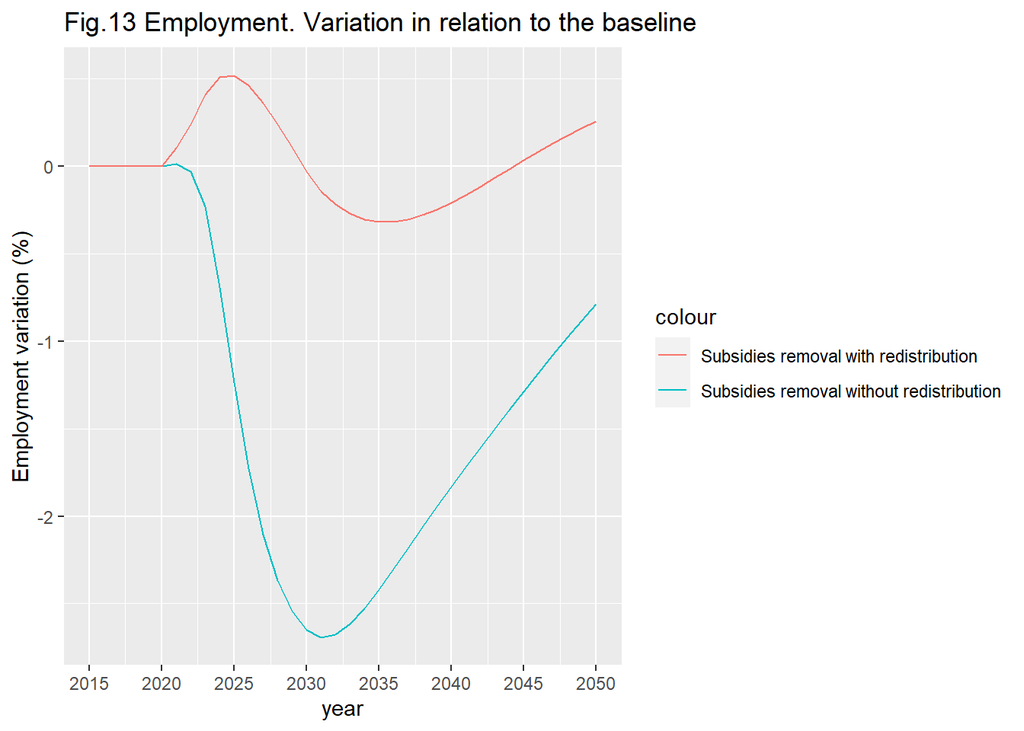

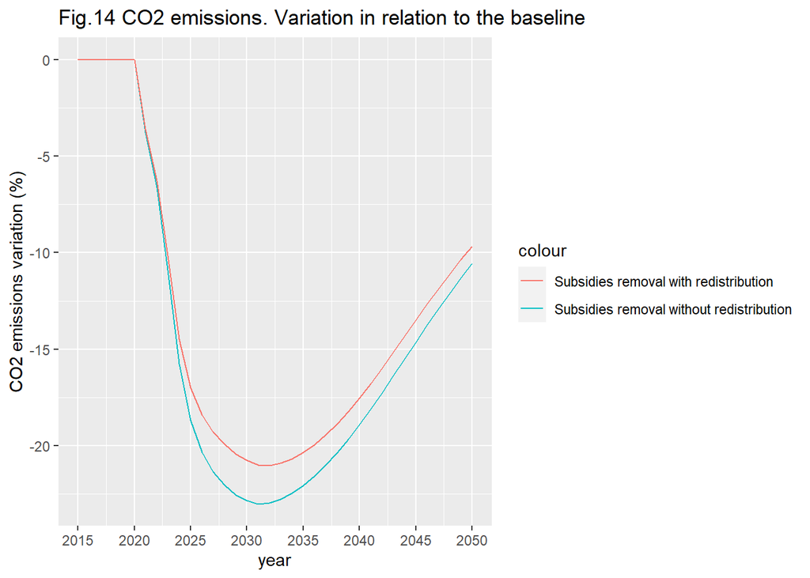

If we observe the variation in the gross salary, we can notice that in the case of carbon tax there is no difference between the scenarios with or without redistribution for this indicator while for the case of fossil fuels subsidies removal, we can observe that the scenario without redistribution presents a higher variation in relation to the baseline.

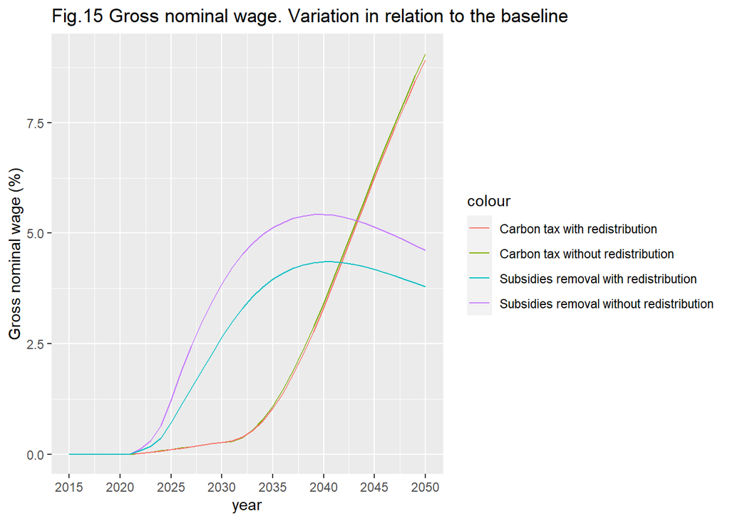

We will now analyse further indicators for the fossil fuels subsidies removal with and without redistribution scenarios. This indicators give us a more complete panorama of the state of the Tunisian economy.

We observe that the redistribution of the fossil fuels subsidies is at the origin of an augmentation in household consumption, however it is much less pronounced that the augmentation that we observed before for the redistribution of the carbon tax. There is in both cases an improvement in the trade balance, but it is more pronounced in the case without redistribution.

Macroeconomic impacts of fossil fuels subsidies removal scenario without redistribution in percent deviation to Baseline

|  | 2021 | 2025 | 2030 | 2035 | 2040 | 2045 | 2050 |
| --- | --- | --- | --- | --- | --- | --- | --- |
| GDP in volume | -0.01 | -1.55 | -2.07 | -1.80 | -1.49 | -1.27 | -1.05 |
| Household consumption | -0.33 | -3.36 | -3.55 | -2.29 | -1.37 | -0.87 | -0.56 |
| Investment | 0.03 | -2.26 | -3.26 | -2.28 | -1.11 | -0.07 | 0.76 |
| Exports | -0.03 | -0.69 | -1.77 | -2.38 | -2.54 | -2.43 | -2.20 |
| Imports | -0.43 | -2.89 | -3.27 | -2.31 | -1.38 | -0.59 | -0.01 |
| Household disposable income | -0.46 | -3.46 | -3.42 | -2.24 | -1.40 | -0.89 | -0.57 |
| Household consumption price index | 0.47 | 3.81 | 5.59 | 6.09 | 5.96 | 5.42 | 4.80 |
| production price index | 0.32 | 3.26 | 5.59 | 6.74 | 6.87 | 6.37 | 5.65 |
| Added value price index | -0.24 | 1.33 | 4.27 | 6.07 | 6.55 | 6.35 | 5.83 |
| Intermediate consumption price index | 0.92 | 5.35 | 7.03 | 7.42 | 7.14 | 6.31 | 5.37 |
| Export price index | 0.50 | 3.26 | 4.76 | 5.05 | 4.84 | 4.35 | 3.79 |
| Import price index | -0.05 | -1.23 | -1.17 | -0.77 | -0.44 | -0.28 | -0.18 |
| Gross nominal wage | 0.00 | 1.24 | 3.85 | 5.12 | 5.42 | 5.14 | 4.62 |
| Real cost of labor | 0.24 | -0.10 | -0.41 | -0.90 | -1.07 | -1.14 | -1.16 |
| Wage employment rate (in thousands) | 0.48 | -47.82 | -105.45 | -97.93 | -75.67 | -53.80 | -33.19 |
| Unemployment rate (in point) | -0.01 | 0.78 | 1.51 | 1.33 | 1.00 | 0.70 | 0.42 |
| Trade balance (in point of GDP) | 0.52 | 3.96 | 4.40 | 3.26 | 2.30 | 1.57 | 1.05 |
| Public budget balance (in points of GDP) | 0.74 | 3.40 | 3.52 | 2.93 | 2.28 | 1.60 | 1.10 |
| Public debt (in points of GDP) | -1.06 | -12.42 | -25.84 | -34.39 | -38.06 | -38.88 | -37.84 |
| CO2 emissions | -3.77 | -18.69 | -22.82 | -22.05 | -18.90 | -14.62 | -10.56 |

Macroeconomic impacts of fossil fuels subsidies removal scenario with redistribution in percent deviation to Baseline

|  | 2021 | 2025 | 2030 | 2035 | 2040 | 2045 | 2050 |
| --- | --- | --- | --- | --- | --- | --- | --- |
| GDP in volume | 0.17 | 0.56 | 0.32 | 0.13 | 0.06 | 0.01 | -0.03 |
| Household consumption | -0.02 | 0.06 | 0.10 | 0.39 | 0.63 | 0.72 | 0.68 |
| Investment | 0.16 | -0.19 | -0.49 | 0.20 | 1.01 | 1.68 | 2.10 |
| Exports | 0.00 | -0.22 | -0.94 | -1.58 | -1.85 | -1.84 | -1.71 |
| Imports | -0.30 | -1.22 | -1.34 | -0.86 | -0.28 | 0.27 | 0.65 |
| Household disposable income | -0.01 | 0.05 | 0.09 | 0.40 | 0.62 | 0.71 | 0.68 |
| Household consumption price index | 0.27 | 2.13 | 3.88 | 4.59 | 4.62 | 4.25 | 3.81 |
| production price index | 0.08 | 1.15 | 3.23 | 4.70 | 5.11 | 4.87 | 4.40 |
| Added value price index | -0.55 | -1.47 | 1.17 | 3.48 | 4.35 | 4.50 | 4.31 |
| Intermediate consumption price index | 0.76 | 3.93 | 5.47 | 6.02 | 5.89 | 5.22 | 4.46 |
| Export price index | 0.36 | 1.89 | 3.15 | 3.70 | 3.69 | 3.37 | 2.98 |
| Import price index | -0.05 | -1.19 | -1.11 | -0.73 | -0.42 | -0.27 | -0.18 |
| Gross nominal wage | 0.01 | 0.71 | 2.64 | 3.95 | 4.35 | 4.18 | 3.79 |
| Real cost of labor | 0.56 | 2.19 | 1.43 | 0.43 | -0.03 | -0.33 | -0.53 |
| Wage employment rate (in thousands) | 3.76 | 20.06 | -1.32 | -12.88 | -8.61 | 1.33 | 10.74 |
| Unemployment rate (in point) | -0.07 | -0.30 | 0.04 | 0.18 | 0.11 | -0.03 | -0.15 |
| Trade balance (in point of GDP) | 0.39 | 2.57 | 2.99 | 2.31 | 1.60 | 1.03 | 0.65 |
| Public budget balance (in points of GDP) | 0.24 | 1.83 | 2.41 | 2.08 | 1.61 | 1.11 | 0.73 |
| Public debt (in points of GDP) | -0.50 | -6.41 | -15.82 | -22.39 | -25.38 | -26.20 | -25.56 |
| CO2 emissions | -3.63 | -17.01 | -20.74 | -20.34 | -17.53 | -13.49 | -9.66 |

After the analyses we made, we can conclude that in general terms scenarios with redistribution produce positive macroeconomic effects in the Tunisian economy. This is the reason why from now on we will only take in consideration the scenarios with redistribution and put aside the scenarios without redistribution.